# Titanic Facts

Antonio Nogueras i Alex Casanovas

1 de junio de 2021

```r
# getwd()
```

# 3. Neteja de les dades de Titanic: all_Titanic.xlsx

```r
library(tidyverse)
```

```r
library(readxl)
library(ggplot2)
```

El fitxers ha sigut tret de la Wikipedia en format Excel

https://en.wikipedia.org/wiki/Crew_of_the_Titanic https://en.wikipedia.org/wiki/Passengers_of_the_Titanic

```r
allT = read_excel("C:/Users/alx/Documents/UOC3/M2.951Tipologia/PRA2/Titanic/all_Titanic.xlsx")
head(allT,3)
```

```
## # A tibble: 3 x 9
##   Name                   Age Boarded Position Lifeboat Body  Sex   Class Group
##   <chr>                <dbl> <chr>   <chr>    <chr>    <chr> <chr> <dbl> <chr>
## 1 "Mr. George Swane"      19 S       chauffe… <NA>     294MB m         2 1class…
## 2 "Miss Amelia Mary \…    18 S       cook     11       <NA>  f         2 1class…
## 3 "Miss Sarah Daniels"    33 S       maid     8        <NA>  f         1 1class…
```

Afegim una columna Survided on ofegat és FALSE i salvat és TRUE

```r
tit=allT %>%
  mutate(Survived=!is.na(Lifeboat))
head(tit)
```

```
## # A tibble: 6 x 10
##   Name           Age Boarded Position Lifeboat Body  Sex   Class Group  Survived
##   <chr>        <dbl> <chr>   <chr>    <chr>    <chr> <chr> <dbl> <chr>  <lgl>
## 1 "Mr. George…    19 S       chauffe… <NA>     294MB m         2 1clas… FALSE
## 2 "Miss Ameli…    18 S       cook     11       <NA>  f         2 1clas… TRUE
## 3 "Miss Sarah…    33 S       maid     8        <NA>  f         1 1clas… TRUE
## 4 "Miss Alice…    22 S       nurse    11       <NA>  f         1 1clas… TRUE
## 5 "Miss Rosal…    46 C       maid     4        <NA>  f         1 1clas… TRUE
## 6 "Miss Carol…    39 C       nurse    4        <NA>  f         1 1clas… TRUE
```

Comprovem si hi ha duplicats de tota una línia

```r
anyDuplicated(tit)
```

```
## [1] 0
```

En tot cas, el nom no és un bon identificador, afegim una columna ID

```r
allT = tit %>%
  mutate(ID = seq(1, nrow(tit), by=1))
head(allT)
```

```
## # A tibble: 6 x 11
##   Name      Age Boarded Position Lifeboat Body  Sex   Class Group Survived    ID
##   <chr>   <dbl> <chr>   <chr>    <chr>    <chr> <chr> <dbl> <chr> <lgl>    <dbl>
## 1 "Mr. G…    19 S       chauffe… <NA>     294MB m         2 1cla… FALSE        1
## 2 "Miss …    18 S       cook     11       <NA>  f         2 1cla… TRUE         2
## 3 "Miss …    33 S       maid     8        <NA>  f         1 1cla… TRUE         3
## 4 "Miss …    22 S       nurse    11       <NA>  f         1 1cla… TRUE         4
## 5 "Miss …    46 C       maid     4        <NA>  f         1 1cla… TRUE         5
## 6 "Miss …    39 C       nurse    4        <NA>  f         1 1cla… TRUE         6
```

Hi ha NA? (menys en Lifeboat i Body, on són acceptables)

```r
any(is.na(allT[-c(5,6)]))
```

```
## [1] TRUE
```

Comprovem en les files crítiques

```r
any(is.na(allT$Age))
```

```
## [1] TRUE
```

```r
any(is.na(allT$Boarded))
```

```
## [1] TRUE
```

```r
any(is.na(allT$Sex))
```

```
## [1] FALSE
```

```r
any(is.na(allT$Class))
```

```
## [1] TRUE
```

```r
any(is.na(allT$Group))
```

```
## [1] FALSE
```

Cas d’Age: comprovem que files són:

```r
allT[is.na(allT$Age), ]
```

```
## # A tibble: 1 x 11
##   Name      Age Boarded Position Lifeboat Body  Sex   Class Group Survived    ID
##   <chr>   <dbl> <chr>   <chr>    <chr>    <chr> <chr> <dbl> <chr> <lgl>    <dbl>
## 1 Dore, …    NA S       Trimmer  <NA>     <NA>  m         0 Engi… FALSE     1402
```

Substituïm el NA per la mediana d’edat del seu grup Enginnering. Primer comprovem les medianes:

```r
grupEdatMed=allT %>%
  group_by(Group) %>%
  summarize(medianE=median(Age,na.rm = T))
grupEdatMed
```

```
## # A tibble: 14 x 2
##    Group       medianE
##    <chr>         <dbl>
##  1 1c0ser           40
##  2 1c1serv          44
##  3 1c2serv          41
##  4 1classServ       33
##  5 2class           29
##  6 3class           24
##  7 Deck             32
##  8 Engineering      30
##  9 garantee         29
## 10 officer          36
## 11 Orchestra        27
## 12 Postman          37
## 13 restaurant       24
## 14 Victualling      31
```

Substituïm el NA per 30

```r
allT$Age = replace_na(allT$Age,30)
```

Cas de Boarded: comprovem que files són:

```r
allT[is.na(allT$Boarded), ]
```

```
## # A tibble: 62 x 11
##    Name     Age Boarded Position Lifeboat Body  Sex   Class Group Survived    ID
##    <chr>  <dbl> <chr>   <chr>    <chr>    <chr> <chr> <dbl> <chr> <lgl>    <dbl>
##  1 Combe…    21 <NA>    Fireman… 3        <NA>  m         0 Engi… TRUE      1378
##  2 Dillo…    25 <NA>    Trimmer  4        <NA>  m         0 Engi… TRUE      1398
##  3 Kench…    37 <NA>    Greaser  <NA>     <NA>  m         0 Engi… FALSE     1478
##  4 Kerr,…    26 <NA>    Fireman… <NA>     <NA>  m         0 Engi… FALSE     1479
##  5 Kinse…    30 <NA>    Fireman… <NA>     <NA>  m         0 Engi… FALSE     1480
##  6 Kirkh…    43 <NA>    Greaser  <NA>     <NA>  m         0 Engi… FALSE     1481
##  7 Lee. …    18 <NA>    Trimmer  <NA>     <NA>  m         0 Engi… FALSE     1484
##  8 Light…    23 <NA>    Fireman… <NA>     <NA>  m         0 Engi… FALSE     1485
##  9 Light…    47 <NA>    Fireman… <NA>     <NA>  m         0 Engi… FALSE     1486
## 10 Long,…    28 <NA>    Trimmer  <NA>     <NA>  m         0 Engi… FALSE     1489
## # … with 52 more rows
```

Segons la Wikipedia, han embarcat tots a Southampton, i reemplacem NA per ‘S’

```r
allT$Boarded = replace_na(allT$Boarded,'S')
```

Cas de Class: comprovem que files són:

```r
allT[is.na(allT$Class), ]
```

```
## # A tibble: 3 x 11
##   Name      Age Boarded Position Lifeboat Body  Sex   Class Group Survived    ID
##   <chr>   <dbl> <chr>   <chr>    <chr>    <chr> <chr> <dbl> <chr> <lgl>    <dbl>
## 1 "Frost…    37 B       Fitter   <NA>     <NA>  m        NA gara… FALSE     2101
## 2 "Knigh…    39 B       Fitter   <NA>     <NA>  m        NA gara… FALSE     2102
## 3 "Parke…    21 B       Plumber  <NA>     <NA>  m        NA gara… FALSE     2103
```

Segons la Wikipedia, aquests components del grup garantee viatgen en 2a classe, i reemplacem NA per 2

```r
allT$Class = replace_na(allT$Class,2)
```

Comprovem, de nou, en les files crítiques:

```r
any(is.na(allT$Age))
```

```
## [1] FALSE
```

```r
any(is.na(allT$Boarded))
```

```
## [1] FALSE
```

```r
any(is.na(allT$Sex))
```

```
## [1] FALSE
```

```r
any(is.na(allT$Class))
```

```
## [1] FALSE
```

```r
any(is.na(allT$Group))
```

```
## [1] FALSE
```

Creem una variable Adult = TRUE si Age > 15

```r
allT = allT %>%
  mutate(Adult = (Age > 15))
head(allT)
```

```
## # A tibble: 6 x 12
##   Name    Age Boarded Position Lifeboat Body  Sex   Class Group Survived    ID
##   <chr> <dbl> <chr>   <chr>    <chr>    <chr> <chr> <dbl> <chr> <lgl>    <dbl>
## 1 "Mr.…    19 S       chauffe… <NA>     294MB m         2 1cla… FALSE        1
## 2 "Mis…    18 S       cook     11       <NA>  f         2 1cla… TRUE         2
## 3 "Mis…    33 S       maid     8        <NA>  f         1 1cla… TRUE         3
## 4 "Mis…    22 S       nurse    11       <NA>  f         1 1cla… TRUE         4
## 5 "Mis…    46 C       maid     4        <NA>  f         1 1cla… TRUE         5
## 6 "Mis…    39 C       nurse    4        <NA>  f         1 1cla… TRUE         6
## # … with 1 more variable: Adult <lgl>
```

Comprovem quants casos hi ha de nens d’edat <= 15

```r
allT %>%
  select(Age) %>%
  summarize(nens = sum(Age <= 15))
```

```
## # A tibble: 1 x 1
##    nens
##   <int>
## 1   134
```

Finalment salvem el fitxer net i amb noves columnes en format csv com ‘allTitanic.csv’

```r
write.csv(allT, "allTitanic.csv")
```

# 4. Anàlisi de les dades

Estructura de les dades llegides:

```r
str(allT)
```

```
## tibble [2,177 × 12] (S3: tbl_df/tbl/data.frame)
##  $ Name    : chr [1:2177] "Mr. George Swane" "Miss Amelia Mary \"Mildred\" Brown" "Miss Sarah Daniels" "Miss Alice Catherine Cleaver" ...
##  $ Age     : num [1:2177] 19 18 33 22 46 39 25 36 38 35 ...
##  $ Boarded : chr [1:2177] "S" "S" "S" "S" ...
##  $ Position: chr [1:2177] "chauffeur" "cook" "maid" "nurse" ...
##  $ Lifeboat: chr [1:2177] NA "11" "8" "11" ...
##  $ Body    : chr [1:2177] "294MB" NA NA NA ...
##  $ Sex     : chr [1:2177] "m" "f" "f" "f" ...
##  $ Class   : num [1:2177] 2 2 1 1 1 1 1 1 1 1 ...
##  $ Group   : chr [1:2177] "1classServ" "1classServ" "1classServ" "1classServ" ...
##  $ Survived: logi [1:2177] FALSE TRUE TRUE TRUE TRUE TRUE ...
##  $ ID      : num [1:2177] 1 2 3 4 5 6 7 8 9 10 ...
##  $ Adult   : logi [1:2177] TRUE TRUE TRUE TRUE TRUE TRUE ...
```

Resum i llistat de NA:

```r
# summary() diu si hi ha NA
summary(allT)
```

```
##      Name                Age           Boarded            Position
##  Length:2177        Min.   : 0.166   Length:2177        Length:2177
##  Class :character   1st Qu.:22.000   Class :character   Class :character
##  Mode  :character   Median :29.000   Mode  :character   Mode  :character
##                     Mean   :29.953
##                     3rd Qu.:36.000
##                     Max.   :74.000
##    Lifeboat             Body               Sex                Class
##  Length:2177        Length:2177        Length:2177        Min.   :0.000
##  Class :character   Class :character   Class :character   1st Qu.:0.000
##  Mode  :character   Mode  :character   Mode  :character   Median :1.000
##                                                           Mean   :1.396
##                                                           3rd Qu.:3.000
##                                                           Max.   :3.000
##     Group            Survived             ID         Adult
##  Length:2177        Mode :logical   Min.   :   1   Mode :logical
##  Class :character   FALSE:1490      1st Qu.: 545   FALSE:134
##  Mode  :character   TRUE :687       Median :1089   TRUE :2043
##                                     Mean   :1089
##                                     3rd Qu.:1633
##                                     Max.   :2177
```

### Seleccionem columnes per l’anàlisi

```r
selT = allT %>%
  select(Age,Boarded,Lifeboat,Sex,Class,Group,Survived)
head(selT,3)
```

```
## # A tibble: 3 x 7
##     Age Boarded Lifeboat Sex   Class Group      Survived
##   <dbl> <chr>   <chr>    <chr> <dbl> <chr>      <lgl>
## 1    19 S       <NA>     m         2 1classServ FALSE
## 2    18 S       11       f         2 1classServ TRUE
## 3    33 S       8        f         1 1classServ TRUE
```

## Estadística de la variable Age numèrica

```r
t.test(allT$Age)
```

```
##
##  One Sample t-test
##
## data:  allT$Age
## t = 118.23, df = 2176, p-value < 2.2e-16
## alternative hypothesis: true mean is not equal to 0
## 95 percent confidence interval:
##  29.45603 30.44965
## sample estimates:
## mean of x
##  29.95284
```

```r
boxplot.stats(selT$Age)
```

```
## $stats
## [1]  1 22 29 36 57
##
## $n
## [1] 2177
##
## $conf
## [1] 28.52592 29.47408
##
## $out
##  [1] 59.000 62.000 71.000 60.000 61.000 59.000 64.000 59.000 70.000 64.000
## [11] 64.000 60.000 60.000 71.000 59.000 58.000 63.000 58.000 64.000 64.000
## [21] 59.000 61.000 62.000 61.000 61.000 63.000 60.000 59.000 58.000 62.000
## [31]  0.916 59.000 58.000 62.000 67.000 63.000 60.000  0.833 62.000 63.000
## [41] 60.000 61.000 71.000 63.000 60.000  0.750  0.833 66.000  0.833  0.750
## [51] 61.000 59.000  0.250  0.166 65.000 63.000 61.000  0.580 62.000 69.000
## [61] 58.000 74.000  0.420 63.000 66.000 62.000 58.000 59.000 60.000 58.000
## [71] 66.000 62.000
```

### Test de normalitat d’Age

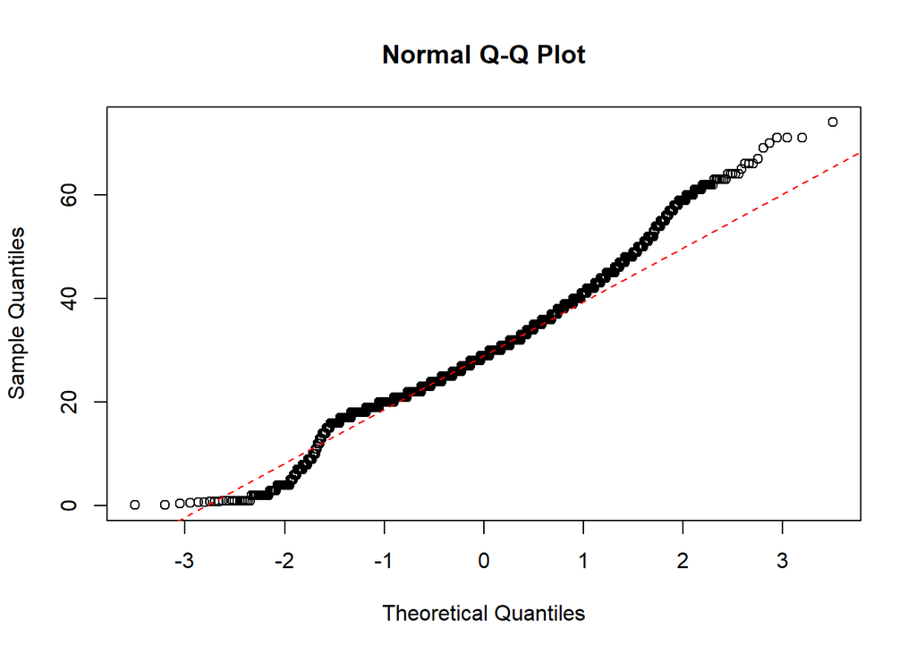

```r
qqnorm(allT$Age) # qqplot  de d. normal
qqline(allT$Age,col=2,lty=2) # reference line
```

### El Q-Q plot confirma la normalitat en les dades vora la mitjana, però discrepa en les cues de la distribució

```r
allTf=allT%>%
  filter(Class==3)
allTm=allT%>%
  filter(Class==1)

t.test(allTm$Age,allTf$Age)
```

```
##
##  Welch Two Sample t-test
##
## data:  allTm$Age and allTf$Age
## t = 16.269, df = 542.32, p-value < 2.2e-16
## alternative hypothesis: true difference in means is not equal to 0
## 95 percent confidence interval:
##  12.42224 15.83389
## sample estimates:
## mean of x mean of y
##  39.11394  24.98587
```